# Grown up steps from R to Python

Alex Bajaña

10/5/2020

In my last article I discussed some differences between syntax in R and Python, my personal conclusion was that each of them has its logic and that’s the richness of open source code: retrieve an environment in which each analist could feel confortable writin in it. In this new article I will follow the same logic: not comparing them in order to say which is better, efficient, or whatever, instead I write for learning and share with everyone who is interested in that goal too. The last part of my past article was named list as we call it in R and dictionaries as they’re called un python. Now it’s time to discuss one of the beauties of prograaming, that I think makes tremendously powerful tool: object oriented programming.

# Classes and objects

There are two key concepts in object oriented programming: objects that have **attributes** and **methods**. An oversimplification could be: if and object has a determined class then the object will first evaluate this class and then will operate accordingly to this class. In my experience this saves a lot of effort when programming because you must not need to create a condition for each element in a certain process, but you must declare how a function (or method) will respond for each possible class that it will encounter.

In R, elements that differ from basic or atomic elements are denominated S3 elements. An example could help us. Imagine a categorical variable, let’s say: gender, it could take two values: “Male” and “Famele”, in this particular case it’s not important and especific order or logic, but what about a variable that describes the level of education of a person, then the variable has an order we must respect like “Basic education”, “Middle eduation”, “College”, “Master degree”. Now if we create a vector with this categories as strings the order does not matter. Let’s see an example: in a survey 300 persons were asked about for their education level, and now we want to see the frequency of each response:

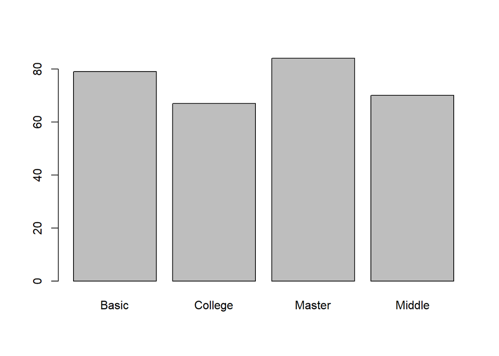

```r
set.seed(1984)

lvl_edu <- sample(x = c("Basic","Middle","College","Master"),size = 300,replace = T)

summ <- table(lvl_edu)


barplot(summ)
```

As you can see in the plot the x labels are ordered alphabetically, but we want the order defined by the variable logic. R has this fabulous object called `factors`, that are S3 objects, first let’s see how this plot changes useng them, then we discuss it’s particularities.

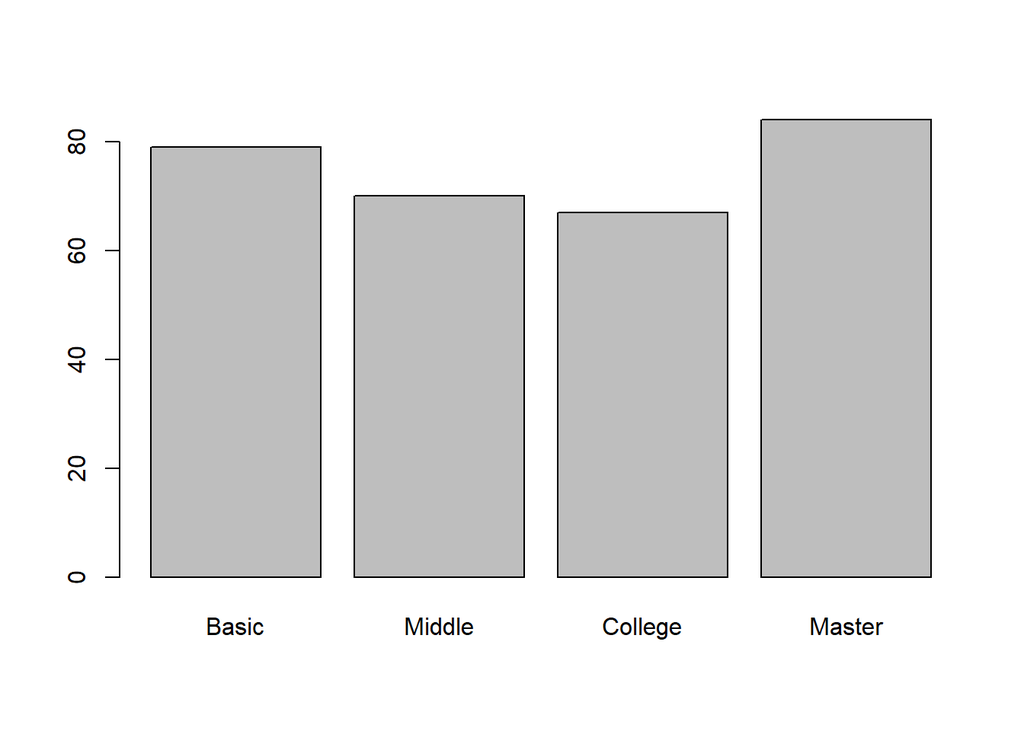

```r
set.seed(1984)

lvl_edu <- sample(x = c("Basic","Middle","College","Master"),size = 300,replace = T)

lvl_edu_f <- factor(lvl_edu,levels = c("Basic","Middle","College","Master"))

summ_2 <- table(lvl_edu_f)

barplot(summ_2)
```

Now we have a correct order of our variable. Some details, always remember to respect the reproducibility principle, this is a really useful concept that I will not discuss here, but I strongly recommend to read about it. Now, set.seed creates a sequence of pseudo random numers, I declare the same in both graphics to compare them, `sample` function creates a sample of given length with the elements of a given vector, the argument replacement allows to have repetitions in the vector, `table` count the times a certain element appear in a vector, really useful summary function. And last `barplot` takes the summary from table and creates a quinck frequency plot.

To the point, in the second graph `factor` function gets the same vector we used in the first plot and with a **ordered** vector creates a variable with a logic or order. But what makes it different from a character vector? The answer will be provided by `attributes` function.

```r
attributes(lvl_edu)
```

[output not shown]

```r
attributes(lvl_edu_f)
```

```
## $levels
## [1] "Basic"   "Middle"  "College" "Master"
##
## $class
## [1] "factor"
```

As you can see, when we check `lvl_edu` object there’s no attribute to show because it still remain as an atomic elemnent. But, if we check the `lvl_edu_f` we see it has two attributes: `levels` and `class`. The existence of this two elements changes the behavior of `barplot` function, changing the order of the lables in our plot.

```r
typeof(lvl_edu)
```

```
## [1] "character"
```

```r
typeof(lvl_edu_f)
```

```
## [1] "integer"
```

```r
print(barplot)
```

```
## function (height, ...)
## UseMethod("barplot")
## <bytecode: 0x0000000013a426f0>
## <environment: namespace:graphics>
```

Discussion about functions will be for other document. Focuss in the `UseMethod("barplot")` sentence, it says that exist a method called “barplot” and will be executed when the `barplot` function is called. Using `methods` function over `barplot` will tell us that this last function will act different when the object is a formula or by default in other case. Let’s see a more ilustrative example.

```r
summary(lvl_edu)
```

```
##    Length     Class      Mode
##       300 character character
```

```r
summary(lvl_edu_f)
```

```
##   Basic  Middle College  Master
##      79      70      67      84
```

Now we can see a bif difference using the method “summary”. Let’s check inside it

```r
methods(summary)
```

```
##  [1] summary.aov                    summary.aovlist*
##  [3] summary.aspell*                summary.check_packages_in_dir*
##  [5] summary.connection             summary.data.frame
##  [7] summary.Date                   summary.default
##  [9] summary.ecdf*                  summary.factor
## [11] summary.glm                    summary.infl*
## [13] summary.lm                     summary.loess*
## [15] summary.manova                 summary.matrix
## [17] summary.mlm*                   summary.nls*
## [19] summary.packageStatus*         summary.POSIXct
## [21] summary.POSIXlt                summary.ppr*
## [23] summary.prcomp*                summary.princomp*
## [25] summary.proc_time              summary.rlang_error*
## [27] summary.rlang_trace*           summary.srcfile
## [29] summary.srcref                 summary.stepfun
## [31] summary.stl*                   summary.table
## [33] summary.tukeysmooth*           summary.warnings
## see '?methods' for accessing help and source code
```

Now we see a collection of many classes that are declared for this method to work with. As you can see, like in `barplot` mehtod we have a behavior declared as default, that it’s used when passing a character vector, and a bahavior declared expecificly for factor. This is the magic of classes and methods.

Now this, not very brief review of classes and methods in R have settled down some concepts to keep our work.